[figure not shown]

**Machine Learning**  
MSE FTP MachLe  
Christoph Würsch

# Solving Frozenlake with Tabular Q-Learning

inspired by: Andrea Pierré

In this exercise, we'll compare a bunch of different map sizes on the [FrozenLake](https://gymnasium.farama.org/environments/toy_text/frozen_lake/)_ environment from the reinforcement learning [Gymnasium](https://gymnasium.farama.org/)_ package using the **Q-learning algorithm**. Let's first import a few dependencies we'll need.

```python
# inspired by: Andrea Pierré
# License: MIT License

from typing import NamedTuple

import matplotlib.pyplot as plt
import numpy as np
import pandas as pd
import seaborn as sns
from tqdm import tqdm

import gymnasium as gym
from gymnasium.envs.toy_text.frozen_lake import generate_random_map


sns.set_theme()

# %load_ext lab_black
```

## Understanding Q-Learning

Q-learning is one of the most widely used algorithms in *Reinforcement Learning* (RL). It belongs to the family of **temporal-difference learning methods** and is an **off-policy algorithm**. Let’s break down the core ideas step by step.

In reinforcement learning, an **agent** interacts with an **environment** in discrete time steps. At each step $t$:

- The agent observes the current **state** $s_t$.
- It chooses an **action** $a\_t$ according to some policy $\pi$.
- The environment returns a **reward** $r_{t+1}$ and the next state $s_{t+1}$.

The goal of the agent is to maximize the *expected cumulative discounted reward*: $$\begin{equation} G_t = \sum_{k=0}^{\infty} \gamma^k r_{t+k+1}, \tag{1} \end{equation}$$ where $\gamma \in [0,1)$ is the *discount factor*. To make good decisions, the agent estimates the **action-value function** $Q(s,a)$: $$\begin{equation} Q^\pi(s,a) = \mathbb{E}_\pi \left[ G_t \;\mid\; s_t = s ; a_t = a \right]. \tag{2} \end{equation}$$

This represents the expected return when starting in state $s$, taking action $a$, and following policy $\pi$ afterward.

The **optimal Q-function** is: $$\begin{equation} Q^*(s,a) = \max_\pi Q^\pi(s,a), \tag{3} \end{equation}$$ which represents the maximum achievable expected return from $(s,a)$. The optimal Q-function satisfies the **Bellman optimality equation**:

$$\begin{equation} Q^*(s,a) = \mathbb{E} \left[ r_{t+1} + \gamma \max_{a'} Q^*(s_{t+1}, a') \;\middle|\; s_t = s, a_t = a \right]. \tag{4} \end{equation}$$ This recursive definition is the foundation of Q-learning.

## The Idea of Q-Learning

Q-learning is a method to *iteratively approximate* $Q^*(s,a)$. At each step, the Q-value is updated using the rule:

$$\begin{equation} \boxed{Q(s_t, a_t) ;\leftarrow; Q(s_t, a_t) + \alpha \Big[ Q_{\text{target}} - Q(s_t, a_t) \Big]}, \tag{5} \end{equation}$$ where $\alpha \in (0,1]$ is the learning rate. The **target value** in Q-learning is:

$$\begin{equation} Q_{\text{target}} = r_{t+1} + \gamma \max_{a'} Q(s_{t+1}, a'). \tag{6} \end{equation}$$

- The first term $r_{t+1}$ is the immediate reward.
- The second term $\gamma \max_{a'} Q(s_{t+1}, a')$ is the best possible future return according to the *current estimate* of $Q$.

This makes Q-learning a **bootstrapping method**: it updates estimates using other current estimates. Q-learning is **off-policy** because:

- The agent may follow any behavior policy (e.g., $\epsilon$-greedy: mostly greedy but sometimes random for exploration).
- However, the update always uses the **greedy action** $\max_{a'} Q(s_{t+1}, a')$ when forming $Q_{\text{target}}$.
- In other words, the agent can explore using $\pi_{\text{behavior}}$, but it *learns* about the **optimal policy** $\pi^*$.

Q-learning is a **temporal difference (TD) learning** method because:

- It updates estimates based on **partially observed returns** (one-step lookahead) rather than waiting for the full episode return (like in Monte Carlo methods).
- The update uses the *TD error*: $$\begin{equation} \delta_t = Q_{\text{target}} - Q(s_t, a_t). \tag{7} \end{equation}$$ This measures the discrepancy between the predicted Q-value and the target.

## Parameters we'll use

```python
class Params(NamedTuple):
    total_episodes: int  # Total episodes
    learning_rate: float  # Learning rate
    gamma: float  # Discounting rate
    epsilon: float  # Exploration probability
    map_size: int  # Number of tiles of one side of the squared environment
    seed: int  # Define a seed so that we get reproducible results
    is_slippery: bool  # If true the player will move in intended direction with probability of 1/3 else will move in either perpendicular direction with equal probability of 1/3 in both directions
    n_runs: int  # Number of runs
    action_size: int  # Number of possible actions
    state_size: int  # Number of possible states
    proba_frozen: float  # Probability that a tile is frozen


params = Params(
    total_episodes=2000,
    learning_rate=0.8,
    gamma=0.95,
    epsilon=0.1,
    map_size=5,
    seed=123,
    is_slippery=False,
    n_runs=20,
    action_size=None,
    state_size=None,
    proba_frozen=0.9,
)
params

# Set the seed
rng = np.random.default_rng(params.seed)
```

## The FrozenLake environment

```python
env = gym.make(
    "FrozenLake-v1",
    is_slippery=params.is_slippery,
    render_mode="rgb_array",
    desc=generate_random_map(
        size=params.map_size, p=params.proba_frozen, seed=params.seed
    ),
)
```

### Creating the Q-table

In this tutorial we'll be using Q-learning as our learning algorithm and $\epsilon$-greedy to decide which action to pick at each step. You can have a look at the References section_ for some refreshers on the theory. Now, let's create our Q-table initialized at zero with the states number as rows and the actions number as columns.

```python
params = params._replace(action_size=env.action_space.n)
params = params._replace(state_size=env.observation_space.n)
print(f"Action size: {params.action_size}")
print(f"State size: {params.state_size}")


class Qlearning:
    def __init__(self, learning_rate, gamma, state_size, action_size):
        self.state_size = state_size
        self.action_size = action_size
        self.learning_rate = learning_rate
        self.gamma = gamma
        self.reset_qtable()

    def update(self, state, action, reward, new_state):
        """Update Q(s,a):= Q(s,a) + lr [R(s,a) + gamma * max Q(s',a') - Q(s,a)]"""
        delta = (
            reward
            + self.gamma * np.max(self.qtable[new_state, :])
            - self.qtable[state, action]
        )
        q_update = self.qtable[state, action] + self.learning_rate * delta
        return q_update

    def reset_qtable(self):
        """Reset the Q-table."""
        self.qtable = np.zeros((self.state_size, self.action_size))
```

```
Action size: 4
State size: 25
```

```python
class EpsilonGreedy:
    def __init__(self, epsilon):
        self.epsilon = epsilon

    def choose_action(self, action_space, state, qtable):
        """Choose an action `a` in the current world state (s)."""
        # First we randomize a number
        explor_exploit_tradeoff = rng.uniform(0, 1)

        # Exploration
        if explor_exploit_tradeoff < self.epsilon:
            action = action_space.sample()

        # Exploitation (taking the biggest Q-value for this state)
        else:
            # Break ties randomly
            # Find the indices where the Q-value equals the maximum value
            # Choose a random action from the indices where the Q-value is maximum
            max_ids = np.where(qtable[state, :] == max(qtable[state, :]))[0]
            action = rng.choice(max_ids)
        return action
```

### Running the environment

Let's instantiate the learner and the explorer.

```python
learner = Qlearning(
    learning_rate=params.learning_rate,
    gamma=params.gamma,
    state_size=params.state_size,
    action_size=params.action_size,
)
explorer = EpsilonGreedy(
    epsilon=params.epsilon,
)
```

This will be our main function to run our environment until the maximum number of episodes `params.total_episodes`. To account for stochasticity, we will also run our environment a few times.

```python
def run_env():
    rewards = np.zeros((params.total_episodes, params.n_runs))
    steps = np.zeros((params.total_episodes, params.n_runs))
    episodes = np.arange(params.total_episodes)
    qtables = np.zeros((params.n_runs, params.state_size, params.action_size))
    all_states = []
    all_actions = []

    for run in range(params.n_runs):  # Run several times to account for stochasticity
        learner.reset_qtable()  # Reset the Q-table between runs

        for episode in tqdm(
            episodes, desc=f"Run {run}/{params.n_runs} - Episodes", leave=False
        ):
            state = env.reset(seed=params.seed)[0]  # Reset the environment
            step = 0
            done = False
            total_rewards = 0

            while not done:
                action = explorer.choose_action(
                    action_space=env.action_space, state=state, qtable=learner.qtable
                )

                # Log all states and actions
                all_states.append(state)
                all_actions.append(action)

                # Take the action (a) and observe the outcome state(s') and reward (r)
                new_state, reward, terminated, truncated, info = env.step(action)

                done = terminated or truncated

                learner.qtable[state, action] = learner.update(
                    state, action, reward, new_state
                )

                total_rewards += reward
                step += 1

                # Our new state is state
                state = new_state

            # Log all rewards and steps
            rewards[episode, run] = total_rewards
            steps[episode, run] = step
        qtables[run, :, :] = learner.qtable

    return rewards, steps, episodes, qtables, all_states, all_actions
```

### Visualization

To make it easy to plot the results with Seaborn, we'll save the main results of the simulation in Pandas dataframes.

```python
def postprocess(episodes, params, rewards, steps, map_size):
    """Convert the results of the simulation in dataframes."""
    res = pd.DataFrame(
        data={
            "Episodes": np.tile(episodes, reps=params.n_runs),
            "Rewards": rewards.flatten(order="F"),
            "Steps": steps.flatten(order="F"),
        }
    )
    res["cum_rewards"] = rewards.cumsum(axis=0).flatten(order="F")
    res["map_size"] = np.repeat(f"{map_size}x{map_size}", res.shape[0])

    st = pd.DataFrame(data={"Episodes": episodes, "Steps": steps.mean(axis=1)})
    st["map_size"] = np.repeat(f"{map_size}x{map_size}", st.shape[0])
    return res, st
```

We want to plot the policy the agent has learned in the end. To do that we will: 1. extract the best Q-values from the Q-table for each state, 2. get the corresponding best action for those Q-values, 3. map each action to an arrow so we can visualize it.

```python
def qtable_directions_map(qtable, map_size):
    """Get the best learned action & map it to arrows."""
    qtable_val_max = qtable.max(axis=1).reshape(map_size, map_size)
    qtable_best_action = np.argmax(qtable, axis=1).reshape(map_size, map_size)
    directions = {0: "←", 1: "↓", 2: "→", 3: "↑"}
    qtable_directions = np.empty(qtable_best_action.flatten().shape, dtype=str)
    eps = np.finfo(float).eps  # Minimum float number on the machine
    for idx, val in enumerate(qtable_best_action.flatten()):
        if qtable_val_max.flatten()[idx] > eps:
            # Assign an arrow only if a minimal Q-value has been learned as best action
            # otherwise since 0 is a direction, it also gets mapped on the tiles where
            # it didn't actually learn anything
            qtable_directions[idx] = directions[val]
    qtable_directions = qtable_directions.reshape(map_size, map_size)
    return qtable_val_max, qtable_directions
```

With the following function, we'll plot on the left the last frame of the simulation. If the agent learned a good policy to solve the task, we expect to see it on the tile of the treasure in the last frame of the video. On the right we'll plot the policy the agent has learned. Each arrow will represent the best action to choose for each tile/state.

```python
def plot_q_values_map(qtable, env, map_size):
    """Plot the last frame of the simulation and the policy learned."""
    qtable_val_max, qtable_directions = qtable_directions_map(qtable, map_size)

    # Plot the last frame
    fig, ax = plt.subplots(nrows=1, ncols=2, figsize=(15, 5))
    ax[0].imshow(env.render())
    ax[0].axis("off")
    ax[0].set_title("Last frame")

    # Plot the policy
    sns.heatmap(
        qtable_val_max,
        annot=qtable_directions,
        fmt="",
        ax=ax[1],
        cmap=sns.color_palette("Blues", as_cmap=True),
        linewidths=0.7,
        linecolor="black",
        xticklabels=[],
        yticklabels=[],
        annot_kws={"fontsize": "xx-large"},
    ).set(title="Learned Q-values\nArrows represent best action")
    for _, spine in ax[1].spines.items():
        spine.set_visible(True)
        spine.set_linewidth(0.7)
        spine.set_color("black")
    plt.show()
```

As a sanity check, we will plot the distributions of states and actions with the following function:

```python
def plot_states_actions_distribution(states, actions, map_size):
    """Plot the distributions of states and actions."""
    labels = {"LEFT": 0, "DOWN": 1, "RIGHT": 2, "UP": 3}

    fig, ax = plt.subplots(nrows=1, ncols=2, figsize=(15, 5))
    sns.histplot(data=states, ax=ax[0], kde=True)
    ax[0].set_title("States")
    sns.histplot(data=actions, ax=ax[1])
    ax[1].set_xticks(list(labels.values()), labels=labels.keys())
    ax[1].set_title("Actions")
    fig.tight_layout()
    plt.show()
```

Now we'll be running our agent on a few increasing maps sizes: - $4 \times 4$, - $7 \times 7$, - $9 \times 9$, - $11 \times 11$.

Putting it all together:

```
Map size: 4x4
```

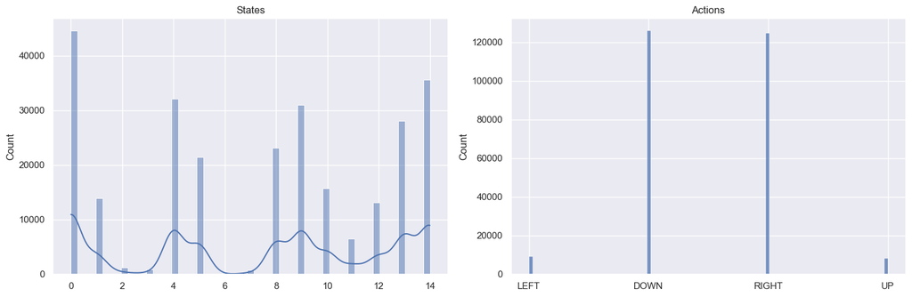

[figure not shown]

```
Map size: 7x7
```

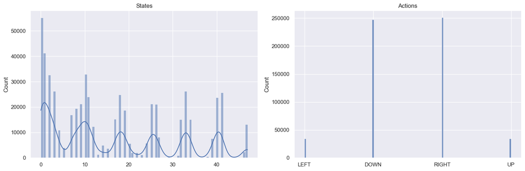

[figure not shown]

```
Map size: 9x9
```

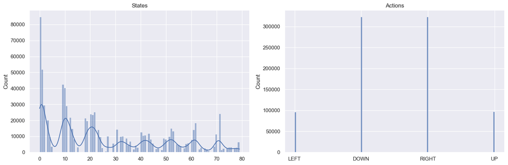

[figure not shown]

```
Map size: 11x11
```

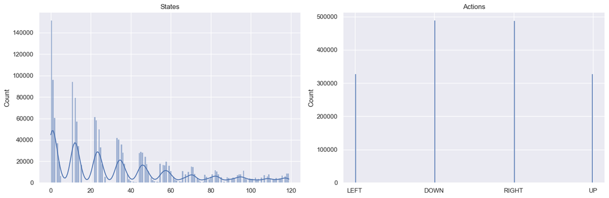

[figure not shown]

```python
map_sizes = [4, 7, 9, 11]
res_all = pd.DataFrame()
st_all = pd.DataFrame()

for map_size in map_sizes:
    env = gym.make(
        "FrozenLake-v1",
        is_slippery=params.is_slippery,
        render_mode="rgb_array",
        desc=generate_random_map(
            size=map_size, p=params.proba_frozen, seed=params.seed
        ),
    )

    params = params._replace(action_size=env.action_space.n)
    params = params._replace(state_size=env.observation_space.n)
    env.action_space.seed(
        params.seed
    )  # Set the seed to get reproducible results when sampling the action space
    learner = Qlearning(
        learning_rate=params.learning_rate,
        gamma=params.gamma,
        state_size=params.state_size,
        action_size=params.action_size,
    )
    explorer = EpsilonGreedy(
        epsilon=params.epsilon,
    )

    print(f"Map size: {map_size}x{map_size}")
    rewards, steps, episodes, qtables, all_states, all_actions = run_env()

    # Save the results in dataframes
    res, st = postprocess(episodes, params, rewards, steps, map_size)
    res_all = pd.concat([res_all, res])
    st_all = pd.concat([st_all, st])
    qtable = qtables.mean(axis=0)  # Average the Q-table between runs

    plot_states_actions_distribution(
        states=all_states, actions=all_actions, map_size=map_size
    )  # Sanity check
    plot_q_values_map(qtable, env, map_size)

    env.close()
```

The `DOWN` and `RIGHT` actions get chosen more often, which makes sense as the agent starts at the top left of the map and needs to find its way down to the bottom right. Also the bigger the map, the less states/tiles further away from the starting state get visited.

To check if our agent is learning, we want to plot the cumulated sum of rewards, as well as the number of steps needed until the end of the episode. If our agent is learning, we expect to see the cumulated sum of rewards to increase and the number of steps to solve the task to decrease.

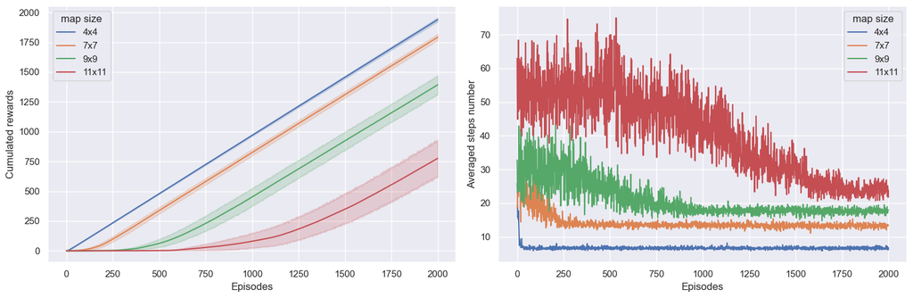

```python
def plot_steps_and_rewards(rewards_df, steps_df):
    """Plot the steps and rewards from dataframes."""
    fig, ax = plt.subplots(nrows=1, ncols=2, figsize=(15, 5))
    sns.lineplot(
        data=rewards_df, x="Episodes", y="cum_rewards", hue="map_size", ax=ax[0]
    )
    ax[0].set(ylabel="Cumulated rewards")

    sns.lineplot(data=steps_df, x="Episodes", y="Steps", hue="map_size", ax=ax[1])
    ax[1].set(ylabel="Averaged steps number")

    for axi in ax:
        axi.legend(title="map size")
    fig.tight_layout()
    plt.show()


plot_steps_and_rewards(res_all, st_all)
```

In the end, if agent doesn't get any rewards, rewards don't get propagated in the Q-values, and the agent doesn't learn anything. In my experience on this environment using $\epsilon$-greedy and those hyperparameters and environment settings, maps having more than $11 \times 11$ tiles start to be difficult to solve. Maybe using a different exploration algorithm could overcome this. The other parameter having a big impact is the `proba_frozen`, the probability of the tile being frozen. With too many holes, i.e. $p<0.9$, Q-learning is having a hard time in not falling into holes and getting a reward signal.

## References

- Code inspired by [Deep Reinforcement Learning Course](https://simoninithomas.github.io/Deep_reinforcement_learning_Course/)_ by Thomas Simonini (http://simoninithomas.com/)
- [Dissecting Reinforcement Learning-Part.2](https://mpatacchiola.github.io/blog/2017/01/15/dissecting-reinforcement-learning-2.html)_
- [David Silver’s course](https://www.davidsilver.uk/teaching/)_ in particular lesson 4 and lesson 5
- [Q-learning article on Wikipedia](https://en.wikipedia.org/wiki/Q-learning)_
- [Q-Learning: Off-Policy TD Control](http://incompleteideas.net/book/ebook/node65.html)_ in [Reinforcement Learning: An Introduction, by Richard S. Sutton and Andrew G. Barto](http://incompleteideas.net/book/ebook/)_
- [Epsilon-Greedy Q-learning](https://www.baeldung.com/cs/epsilon-greedy-q-learning)_
- [Introduction to Reinforcement Learning](https://gibberblot.github.io/rl-notes/index.html)_ by Tim Miller (University of Melbourne)